# Explore obesity category distribution and predictor characteristics

Saeed Zohoorian

2025-08-22

# **Introduction**

Obesity is a major public health concern influenced by lifestyle, diet, and behavioral patterns. Understanding these factors can help design effective interventions.

In this project, we aim to model the relationship between lifestyle factors and **obesity categories** (ordinal variable) using **Bayesian Ordinal Regression**. Unlike linear models, ordinal regression is suitable for ordered outcomes, and the Bayesian approach allows incorporation of prior knowledge and full uncertainty quantification.

# **Objective**

- Explore obesity category distribution and predictor characteristics.
- Build a **Bayesian ordinal regression** model to predict obesity category.
- Interpret probabilistic effects of predictors.

## Dataset Overview

The dataset used in this study contains information for estimating obesity levels in individuals from **Mexico, Peru, and Colombia**.  
It includes **2111 records** with **17 attributes** describing eating habits, physical conditions, and lifestyle factors.  
The target variable is **Obesity_category**, which represents ordered levels of obesity.

### Data Composition

- **77%** of the data was synthetically generated using **Weka + SMOTE**.
- **23%** was collected directly from users through a web platform.

### Variables

The dataset includes both **continuous** and **categorical** predictors:

- **Demographic**:
  - `Gender`: Gender of the individual.
  - `Age`: Age (in years).
  - `Height`: Height (in meters).
  - `Weight`: Weight (in kilograms).
- **Family/Medical**:
  - `family_history_with_overweight`: Whether a family member has suffered from overweight (Yes/No).
- **Dietary habits**:
  - `FAVC`: Frequent consumption of high-caloric food (Yes/No).
  - `FCVC`: Frequency of vegetable consumption in meals (scale 1–3).
  - `NCP`: Number of main meals per day.
  - `CAEC`: Food consumption between meals (Never, Sometimes, Frequently, Always).
  - `CH2O`: Daily water consumption (liters).
  - `CALC`: Alcohol consumption frequency (Never, Sometimes, Frequently, Always).
- **Lifestyle/Behavior**:
  - `SMOKE`: Smoking habit (Yes/No).
  - `SCC`: Monitoring of daily calorie consumption (Yes/No).
  - `FAF`: Physical activity frequency (hours per week).
  - `TUE`: Time spent daily using technology devices (hours).
  - `MTRANS`: Main mode of transportation (Walking, Bike, Public Transport, Car, Motorcycle).
- **Target variable**:
  - `NObeyesdad`: Obesity level (Insufficient Weight, Normal Weight, Overweight I, Overweight II, Obesity I, Obesity II, Obesity III).

|  | Gender | Age | Height | Weight | family_history_with_overweight | FAVC | FCVC | NCP | CAEC | SMOKE | CH2O | SCC | FAF | TUE | CALC | MTRANS | Obesity_category |
| --- | --- | --- | --- | --- | --- | --- | --- | --- | --- | --- | --- | --- | --- | --- | --- | --- | --- |
| 1 | Female | 21 | 1.62 | 64.0 | yes | no | 2 | 3 | Sometimes | no | 2 | no | 0 | 1 | no | Public_Transportation | Normal_Weight |
| 2 | Female | 21 | 1.52 | 56.0 | yes | no | 3 | 3 | Sometimes | yes | 3 | yes | 3 | 0 | Sometimes | Public_Transportation | Normal_Weight |
| 3 | Male | 23 | 1.80 | 77.0 | yes | no | 2 | 3 | Sometimes | no | 2 | no | 2 | 1 | Frequently | Public_Transportation | Normal_Weight |
| 4 | Male | 27 | 1.80 | 87.0 | no | no | 3 | 3 | Sometimes | no | 2 | no | 2 | 0 | Frequently | Walking | Overweight_Level_I |
| 5 | Male | 22 | 1.78 | 89.8 | no | no | 2 | 1 | Sometimes | no | 2 | no | 0 | 0 | Sometimes | Public_Transportation | Overweight_Level_II |

## Data Preparation and EDA

The dataset used in this project is the **UCI Obesity Dataset** (*Estimation of Obesity Levels Based on Eating Habits and Physical Condition*), available at:  
[UCI Obesity Dataset](https://archive.ics.uci.edu/dataset/544/estimation+of+obesity+levels+based+on+eating+habits+and+physical+condition).

The data was first fetched in **Google Colab (Python)** and saved as (`obesity_raw.csv`) for import into **R**.  
Subsequently, **exploratory data analysis (EDA)** was carried out to select appropriate variables, verify data quality, and ensure the dataset was consistent and suitable for further statistical modeling.

### Distribution of Obesity Levels

The target variable `NObeyesdad` was examined to understand class balance.  
The distribution is fairly even across categories, which is beneficial for classification tasks:

- All obesity levels (Normal, Overweight I & II, Obesity I–III, Insufficient Weight) are well represented.
- **Obesity Type I** has the highest count, while **Insufficient Weight** has the lowest.
- The relatively balanced distribution suggests that the model will not suffer significantly from class imbalance.

This makes the dataset particularly suitable for **ordinal classification approaches**, such as Bayesian ordinal regression.

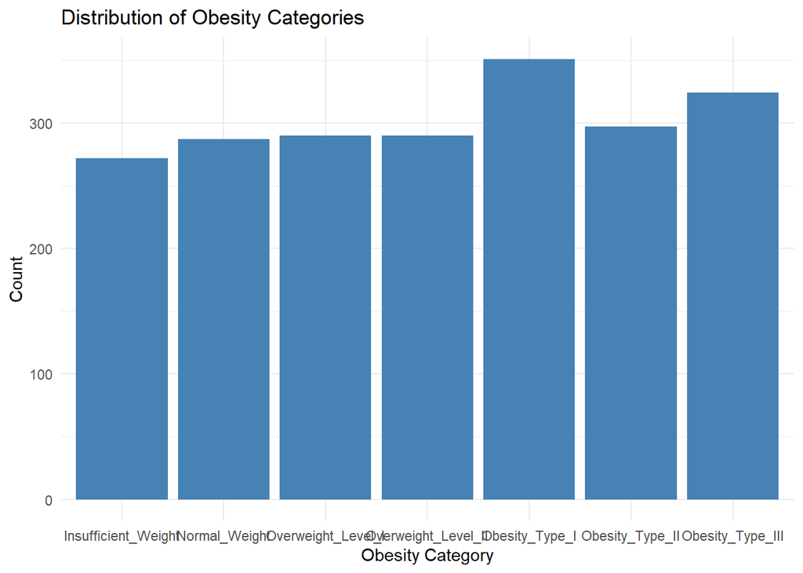

## **Relationship Between Continuous Predictors and Obesity Levels**

According to the **boxplots of each continuous variable against the obesity categories**, several clear patterns emerge:

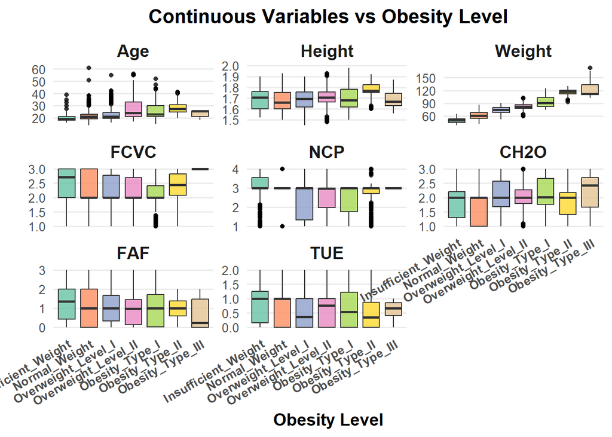

### Interpretation:

Weight and age provide the strongest separation across obesity categories. Lifestyle-related variables such as **physical activity** and **vegetable intake** also show meaningful trends, reinforcing the link between daily habits and obesity progression. Meanwhile, water intake and technology use show smaller but consistent differences.

## Summary of Continuous Variables by Obesity Category

To understand how continuous variables relate to obesity levels **histograms and density plots** were examined to visualize distributions and overlaps between categories.

### Key Observations

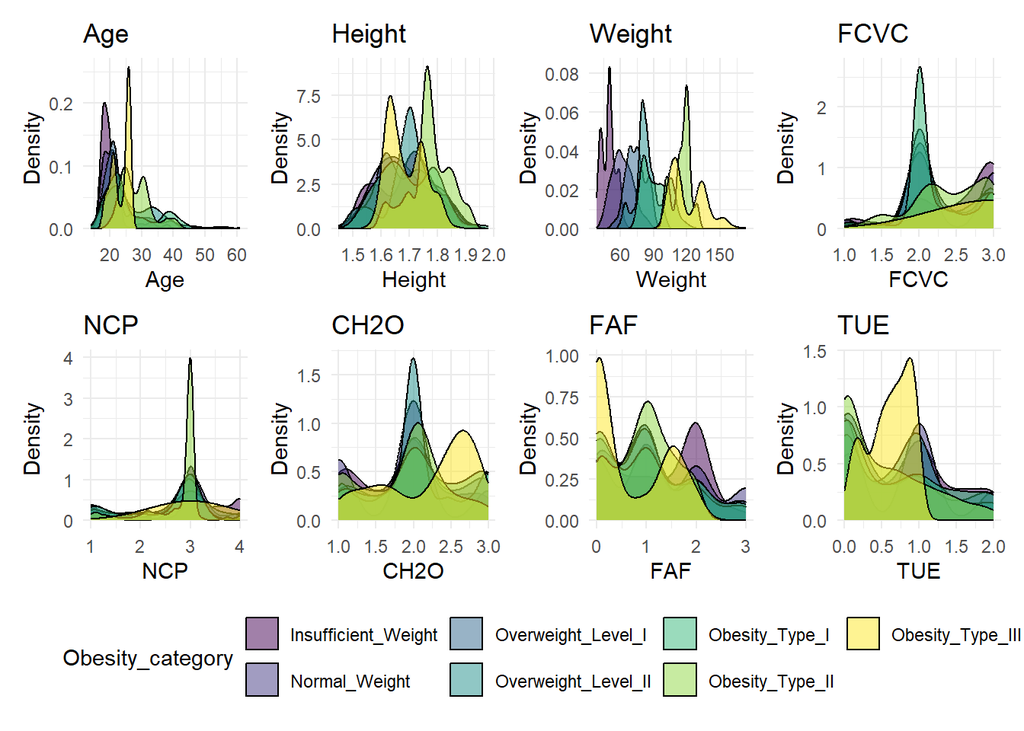

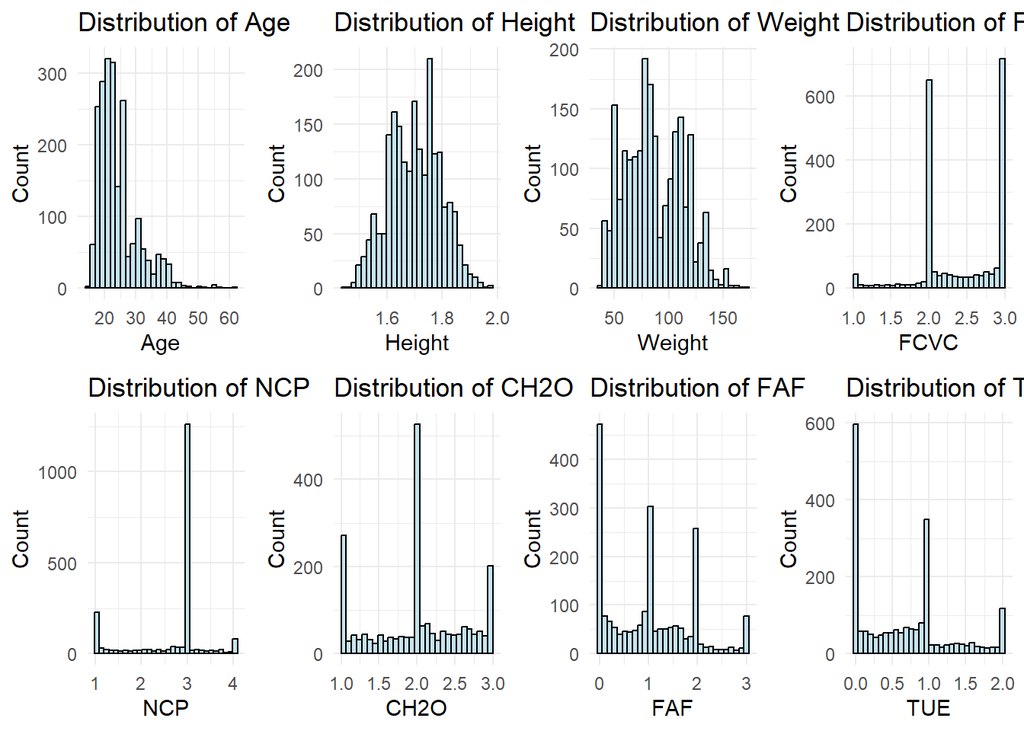

### Interpretation

- **Strongest continuous predictors:**
  - `Weight` and `Age` provide the clearest separation across obesity categories.
- **Moderate predictors:**
  - `FAF` and `FCVC` show some trends aligned with obesity levels.
- **Weak predictors:**
  - `Height`, `NCP`, `CH2O`, and `TUE` show substantial overlap across categories.

## **Relationship Between Categorical Predictors and Obesity Levels**

To better understand how lifestyle and behavioral variables relate to obesity, we examined the distribution of **categorical predictors** across the different obesity categories.  
The figure below shows bar plots for each categorical variable against `Obesity_category`.

**Key observations:**

### Gender

- Both males and females are represented across all levels.
- Females appear more in the higher obesity categories.
- Males dominate moderate obesity groups.

### Family History with Overweight

- Strong link: those with family history are more likely obese.
- No family history → more normal/underweight cases.

### High-Calorie Food Consumption (FAVC)

- Frequent consumption is clearly tied to obesity.
- Avoiding high-calorie food is common in normal weight cases.

### Eating Between Meals (CAEC)

- Occasional snacking is strongly linked to obesity.
- Never snacking → more overweight than obese.
- Frequent/always snacking → mixed distribution.

### Smoking

- Both smokers and non-smokers appear in obese groups.
- No clear protective effect of smoking.

### Calories Monitoring (SCC)

- Weak impact.
- Tracking calories does not consistently reduce obesity.

### Alcohol Consumption (CALC)

- All categories present across drinking habits.
- Alcohol use alone is not decisive.

### Transportation Mode (MTRANS)

- Public transport use is common in obese groups.
- Walking/biking more linked to normal weight.
- Car users spread across overweight/obese.

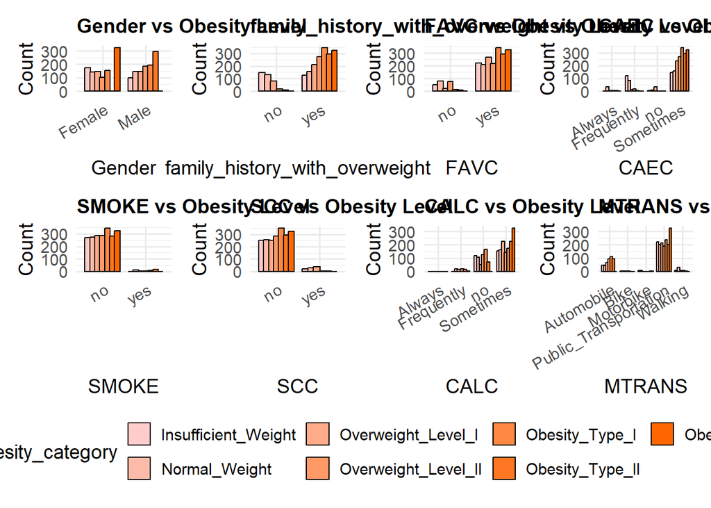

### Interpretation:

Lifestyle factors (family history, high-calorie food, snacking habits) show the strongest links to obesity, while smoking, alcohol, and calorie monitoring have weaker associations.

## Proportion Analysis of Categorical Variables

To better understand the relationship between categorical predictors and obesity categories, we computed the **proportion of individuals in each obesity level within each category**.  
This approach allows us to compare relative likelihoods across categories, independent of category size.

### Key Observations

1. **Gender**
   - Females tend to appear more in the higher obesity categories, while males are more common in moderate obesity groups.
   - This suggests a potential gender-based trend in obesity levels.
2. **Family History with Overweight**
   - Individuals with a family history of overweight are more likely to fall into higher obesity categories.
   - Those without such a history are more frequently found in lower obesity categories.
   - Indicates that family history is an important predictor of obesity.
3. **High-Calorie Food Consumption (FAVC)**
   - Frequent consumers of high-calorie foods are more likely to be in higher obesity categories.
   - Non-consumers tend to appear in lower obesity categories.
4. **Eating Between Meals (CAEC)**
   - Occasional or frequent snacking is associated with higher obesity levels.
   - People who rarely or always snack are more often in lower obesity categories.
5. **Smoking (SMOKE)**
   - Smokers appear across all obesity categories, with no clear protective or risk pattern evident.
6. **Calorie Monitoring (SCC)**
   - Tracking calories does not show a consistent association with obesity levels.
   - The impact appears weak across the categories.
7. **Alcohol Consumption (CALC)**
   - Alcohol consumption patterns are mixed and do not clearly correspond to specific obesity levels.
8. **Transportation Mode (MTRANS)**
   - Car users tend to appear more in moderate obesity categories.
   - Walking or biking is more common among lower obesity categories.
   - Public transportation users are distributed across all obesity levels.

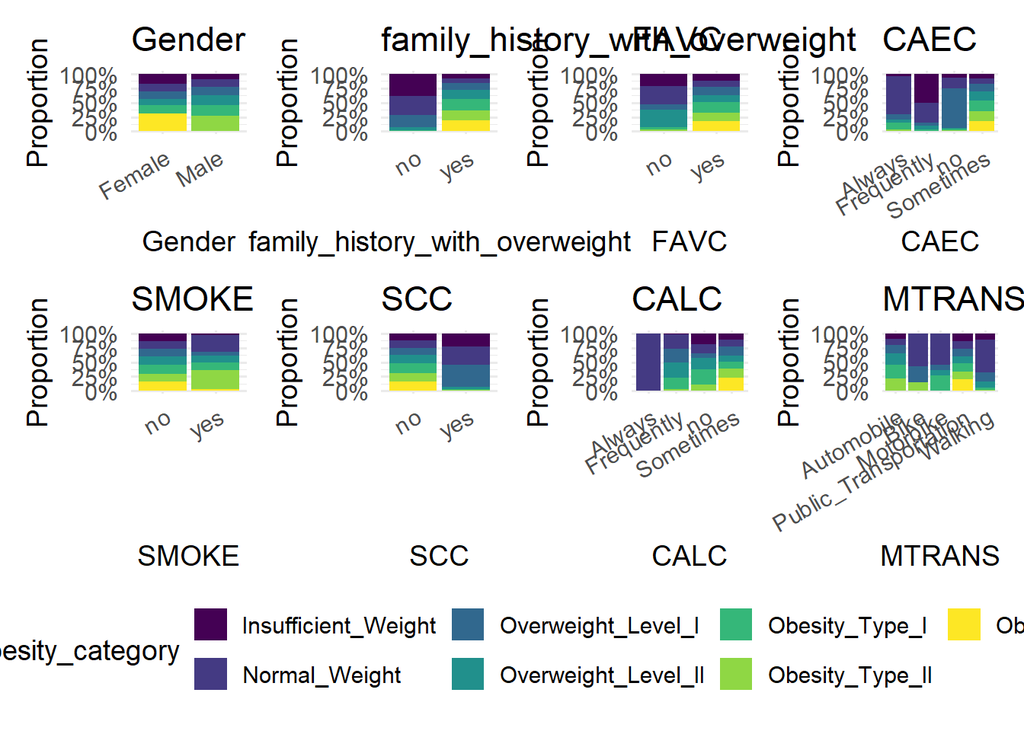

### Interpretation

- **Strongest categorical predictors:**
  - `family_history_with_overweight`, `FAVC`, and `CAEC`.
  - These variables demonstrate noticeable shifts in obesity proportions.
- **Weaker predictors:**
  - `SMOKE`, `SCC`, `CALC`, `MTRANS` — show more uniform distribution across obesity categories.

### Feature Importance Analysis

We applied **three different approaches** to evaluate the predictors:

### 1. Mutual Information (MI)

MI measures how much knowing a predictor reduces uncertainty about the target variable. Higher MI indicates stronger relevance to predicting obesity levels.

- **Most informative predictors:**
  - `Weight` and `Age` have the highest MI scores, indicating they provide the most information about obesity categories.
  - Lifestyle-related variables such as `FCVC` (vegetable consumption), `FAF` (physical activity), and `TUE` (technology use) also show moderate information.
- **Moderately informative predictors:**
  - `CH2O` (water intake), `NCP` (number of main meals), and `Gender` have moderate MI, suggesting some contribution to obesity prediction.
- **Weak predictors:**
  - Variables like `SCC` (calorie monitoring), `SMOKE` (smoking), `FAVC` (high-calorie food consumption), and `MTRANS` (transportation mode) show low MI scores, indicating minimal predictive power individually.

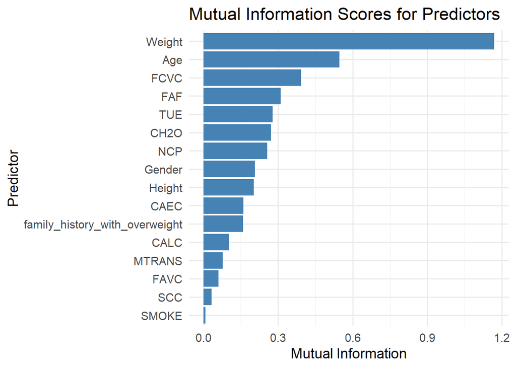

### 2. Correlation Analysis

To assess potential redundancy among continuous predictors, we computed the **pairwise correlation matrix**. This helps identify multicollinearity, which can affect model stability and interpretability.

### Key Observations

- Most correlations are **weak to moderate**, suggesting that the predictors largely provide independent information.
- **Highest correlation** observed is between `Weight` and `Height` (r ≈ 0.46), indicating a moderate positive relationship.
- Other correlations are low, generally below 0.3, confirming **low multicollinearity** among the remaining variables.

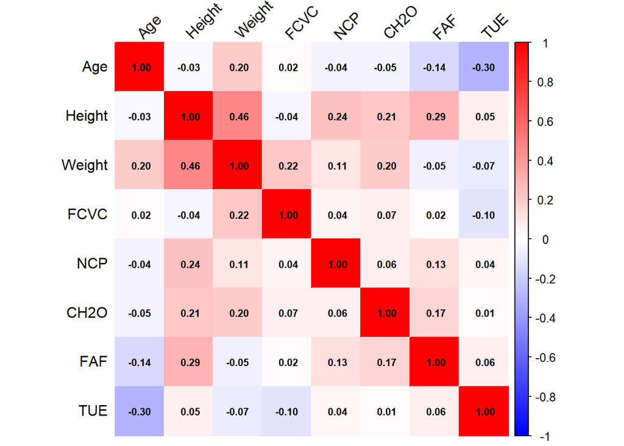

### Implications for Data Preparation

- `Weight` and `Height` are moderately correlated; in models sensitive to multicollinearity (e.g., linear regression), we could consider:
  - Standardizing variables, or
  - Creating a derived feature such as **BMI** (`Weight / Height^2`) to capture body mass in a single metric, which is also more interpretable in obesity prediction.

### 3. Statistical and Model-Based Feature Selection

To prepare predictors for the Bayesian Ordinal Regression model, we conducted a systematic feature selection process. The goal was to balance **predictive strength** and **model interpretability**, while avoiding unnecessary complexity in the Bayesian framework.

### Evaluation Methods

We applied multiple complementary approaches to assess feature importance:

1. **Mutual Information (MI)** – quantified the information each feature provides about the `Obesity_category`.
2. **Statistical Tests**
   - **ANOVA F-test** (continuous predictors vs. obesity category)
   - **Chi-Square test** (categorical predictors vs. obesity category)
3. **Random Forest Feature Importance** – model-based measure of predictive contribution.

By combining these rankings, we identified features that consistently demonstrated high or low importance.

### Results Summary

```
##                                                       Feature     ANOVA_F
## Weight                                                 Weight 1966.518018
## Age                                                       Age   77.954154
## Height                                                 Height   38.432313
## Gender                                                 Gender          NA
## FCVC                                                     FCVC  112.315462
## CAEC                                                     CAEC          NA
## CH2O                                                     CH2O   16.171142
## FAF                                                       FAF   17.484200
## NCP                                                       NCP   26.811662
## family_history_with_overweight family_history_with_overweight          NA
## TUE                                                       TUE    7.876656
## FAVC                                                     FAVC          NA
## CALC                                                     CALC          NA
## MTRANS                                                 MTRANS          NA
## SCC                                                       SCC          NA
## SMOKE                                                   SMOKE          NA
##                                     Chi2 RF_Importance ANOVA_Rank Chi2_Rank
## Weight                                NA    132.746607          1        NA
## Age                                   NA     47.850819          3        NA
## Height                                NA     57.855630          4        NA
## Gender                         657.74623     41.700449         NA         2
## FCVC                                  NA     38.014927          2        NA
## CAEC                           802.97728     32.685593         NA         1
## CH2O                                  NA     43.062709          7        NA
## FAF                                   NA     37.012521          6        NA
## NCP                                   NA     35.979352          5        NA
## family_history_with_overweight 621.97944     29.019673         NA         3
## TUE                                   NA     36.283319          8        NA
## FAVC                           233.34130     30.279061         NA         6
## CALC                           338.57752     27.515616         NA         4
## MTRANS                         292.59395     25.005232         NA         5
## SCC                            123.02390     15.941655         NA         7
## SMOKE                           32.13783      2.847354         NA         8
##                                RF_Rank RankScore
## Weight                               1       1.0
## Age                                  3       3.0
## Height                               2       3.0
## Gender                               5       3.5
## FCVC                                 6       4.0
## CAEC                                10       5.5
## CH2O                                 4       5.5
## FAF                                  7       6.5
## NCP                                  9       7.0
## family_history_with_overweight      12       7.5
## TUE                                  8       8.0
## FAVC                                11       8.5
## CALC                                13       8.5
## MTRANS                              14       9.5
## SCC                                 15      11.0
## SMOKE                               16      12.0
```

### Final Feature Selection

Based on the combined evidence, we recommend **removing weak predictors** to improve Bayesian model efficiency without losing interpretability.

- **Remove:**
  - `SMOKE` (Smoking)
  - `SCC` (Calorie monitoring)
  - `FAVC` (High-calorie food consumption)
  - `CALC` (Alcohol consumption)
  - `MTRANS` (Transportation mode)
- **Keep:**
  - `Weight`
  - `Age`
  - `Height`
  - `Gender`
  - `FCVC` (Vegetable consumption)
  - `NCP` (Number of main meals)
  - `CH2O` (Water consumption)
  - `FAF` (Physical activity)
  - `CAEC` (Snacking habits)
  - `family_history_with_overweight`
  - `TUE` (Technology use)

### Conclusion

The final feature set balances **biological predictors** (e.g., weight, age, height, gender), **behavioral variables** (diet, activity, technology use), and **family history**, while excluding low-utility variables. This streamlined set will be used in the **Bayesian Ordinal Regression Model** to ensure efficient inference and robust interpretation of obesity predictors.

### **Feature Engineering: Adding BMI**

**Observation from EDA:**

- Boxplots showed that **Weight** had the strongest separation across obesity categories.
- **Height**, while less predictive on its own, influences body size and should be considered to avoid misinterpretation.
- A tall person might weigh more but still have a healthy body composition, so weight alone can be misleading.

To better capture body size, we engineered a new feature **BMI** using the standard clinical formula:
$$BMI = \frac{Weight}{Height^2}$$

While **Weight** showed the strongest separation across obesity categories, it does not account for differences in **Height**.  
By replacing `Weight` and `Height` with **BMI**, we reduce redundancy and multicollinearity, while providing a clinically recognized and interpretable measure of body composition.  
This ensures that the model evaluates obesity risk on a normalized scale rather than raw body measurements.

## Data Preprocessing

We prepared the dataset by selecting only the predictors retained from feature selection, excluding weak variables such as `SMOKE`, `SCC`, `FAVC`, `CALC`, and `MTRANS`.  
Binary predictors (`Gender`, `family_history_with_overweight`) were encoded as 0/1, and continuous predictors were standardized for comparability.  
The categorical variable `CAEC` was converted into an ordered factor with levels `no < Sometimes < Frequently < Always`.  
Finally, dummy variables (`CAEC_Sometimes`, `CAEC_Frequently`, `CAEC_Always`) were created with `"no"` as the reference category, ensuring the dataset is ready for Bayesian ordinal regression.

|  | Gender | Age | FamHist_Overweight | Veg_Freq | Meals_Per_Day | Water_Intake | PhysAct_Freq | Tech_Use | Obesity_category | BMI | CAEC_Sometimes | CAEC_Frequently | CAEC_Always |
| --- | --- | --- | --- | --- | --- | --- | --- | --- | --- | --- | --- | --- | --- |
| 1 | 0 | -0.5220007 | 1 | -0.7848327 | 0.404057 | -0.01307017 | -1.187758 | 0.5618636 | Normal_Weight | -0.6632641 | 1 | 0 | 0 |
| 2 | 0 | -0.5220007 | 1 | 1.0880839 | 0.404057 | 1.61837509 | 2.339196 | -1.0803687 | Normal_Weight | -0.6817753 | 1 | 0 | 0 |
| 3 | 1 | -0.2068400 | 1 | -0.7848327 | 0.404057 | -0.01307017 | 1.163545 | 0.5618636 | Normal_Weight | -0.7407911 | 1 | 0 | 0 |
| 4 | 1 | 0.4234815 | 0 | 1.0880839 | 0.404057 | -0.01307017 | 1.163545 | -1.0803687 | Overweight_Level_I | -0.3555345 | 1 | 0 | 0 |
| 5 | 1 | -0.3644203 | 0 | -0.7848327 | -2.166509 | -0.01307017 | -1.187758 | -1.0803687 | Overweight_Level_II | -0.1694821 | 1 | 0 | 0 |

# Bayesian Analysis

In this section of the project, we will employ a **Bayesian Ordinal Regression Model** using **Modular JAGS** to analyze the relationship between several predictors and an ordinal outcome variable (`Obesity_category`). Unlike standard linear or logistic regression, ordinal regression is specifically designed for ordered categorical outcomes, which makes it ideal for this analysis.

Bayesian models are particularly suitable because they allow us to incorporate prior beliefs and quantify uncertainty through posterior distributions. Furthermore, we will use **two modular JAGS models** to handle parameter estimation, model diagnostics, and posterior predictive checks (PPC).

## **Bayesian Ordinal Regression Model**

### Why Ordinal Regression?

The response variable, `Obesity_category`, is an ordinal variable with multiple ordered categories (e.g., *Normal*, *Overweight*, *Obese*). Standard linear regression is inappropriate because the outcome is not continuous, and simple multinomial models ignore the ordering information. Therefore, an **ordinal logistic model** is chosen, extended into a Bayesian framework for flexibility and uncertainty estimation.

### Model Specification

The ordinal model uses a cumulative logit link:

$$\text{logit}\big( P(Y_i \leq k) \big) = \alpha_k - \mathbf{x}_i^\top
\beta$$

- $Y_i$ is the obesity category for individual $i$.
- $\alpha_k$ are the ordered cutpoints (thresholds) that separate categories.
- $\beta$ is the vector of regression coefficients.
- The probability of each category is computed from the cumulative probabilities.

In JAGS, this is implemented using **cutpoints** and a set of **incremental priors** to ensure ordering constraints.

## Priors

We use **weakly informative priors** to let the data dominate but avoid extreme values:

- $\beta_j \sim \text{Normal}(0, 0.01)$ for all predictors.
- Cutpoints are ordered via exponential increments:
  - $\text{cutpoints}[1] \sim \text{Normal}(0, 0.01)$
  - $\delta_k \sim \text{Normal}(0, 0.01)$, and $\text{cutpoints}[k] = \text{cutpoints}[k-1] + e^{\delta_k}$

This ensures monotonic ordering of thresholds.

## Data & Predictors

```
##
## Interpretation: Prepared design matrix X with 12 predictors and 2111 observations.
```

```
## Obesity target has 7 ordered categories.
```

## **MODELS**

### 2.1 **Base Model with Log-Likelihood**

This model estimates the regression coefficients (`β`) and ordered cutpoints for the ordinal outcome. It assumes proportional odds, meaning predictors have the same effect across thresholds. Log-likelihoods (`ll[i]`) are computed for WAIC and LOO model comparison. The model uses weakly informative priors to allow flexibility without strong assumptions.

```
##
## Iterations = 3001:8000
## Thinning interval = 1
## Number of chains = 3
## Sample size per chain = 5000
##
## 1. Empirical mean and standard deviation for each variable,
##    plus standard error of the mean:
##
##                   Mean     SD  Naive SE Time-series SE
## beta[1]       -1.20173 0.2363 0.0019295       0.006787
## beta[2]       -0.04937 0.1017 0.0008301       0.001502
## beta[3]        0.46870 0.2911 0.0023767       0.010232
## beta[4]       -0.13712 0.1119 0.0009138       0.001706
## beta[5]        0.14136 0.1010 0.0008250       0.001495
## beta[6]        0.06155 0.1062 0.0008669       0.001822
## beta[7]       -0.10807 0.1111 0.0009073       0.001509
## beta[8]       -0.08426 0.1000 0.0008167       0.001652
## beta[9]       28.56492 1.4782 0.0120692       0.365398
## beta[10]       1.54226 0.6372 0.0052026       0.054015
## beta[11]       0.24033 0.7251 0.0059205       0.054502
## beta[12]       0.71317 0.8278 0.0067593       0.050619
## cutpoints[1] -38.41835 2.2762 0.0185849       0.736464
## cutpoints[2] -16.79463 1.1850 0.0096751       0.182969
## cutpoints[3]  -8.61619 0.8991 0.0073410       0.119488
## cutpoints[4]   2.48328 0.7289 0.0059512       0.045138
## cutpoints[5]  18.28794 1.0790 0.0088097       0.101211
## cutpoints[6]  33.53800 1.7186 0.0140321       0.245016
##
## 2. Quantiles for each variable:
##
##                   2.5%       25%       50%       75%     97.5%
## beta[1]       -1.67860  -1.35646  -1.19795  -1.04441  -0.74484
## beta[2]       -0.24887  -0.11728  -0.04979   0.01810   0.14989
## beta[3]       -0.11642   0.27570   0.47305   0.66834   1.02836
## beta[4]       -0.35563  -0.21209  -0.13711  -0.06147   0.08044
## beta[5]       -0.05397   0.07326   0.13940   0.21027   0.33933
## beta[6]       -0.14479  -0.01071   0.06087   0.13212   0.27098
## beta[7]       -0.32952  -0.18184  -0.10866  -0.03399   0.11040
## beta[8]       -0.27763  -0.15243  -0.08422  -0.01816   0.11612
## beta[9]       25.75724  27.64703  28.54210  29.40890  31.59403
## beta[10]       0.34719   1.12312   1.51890   1.95213   2.82727
## beta[11]      -1.13169  -0.25650   0.22849   0.70786   1.74227
## beta[12]      -0.87762   0.14833   0.70012   1.26663   2.35746
## cutpoints[1] -42.85996 -39.83468 -38.44149 -36.99329 -33.81945
## cutpoints[2] -19.03093 -17.55350 -16.83419 -16.04761 -14.41646
## cutpoints[3] -10.33673  -9.22267  -8.64805  -8.02919  -6.71932
## cutpoints[4]   1.08541   1.98018   2.46933   2.97711   3.95402
## cutpoints[5]  16.32600  17.55226  18.23315  18.97507  20.61182
## cutpoints[6]  30.38056  32.43731  33.45054  34.56619  37.36456
```

# Base Model Summary

#### **Convergence diagnostic**

For the evaluation of the MCMC convergence *Traceplot*, *density plot* and *Rhat* from the model summary were used.

*Traceplot*

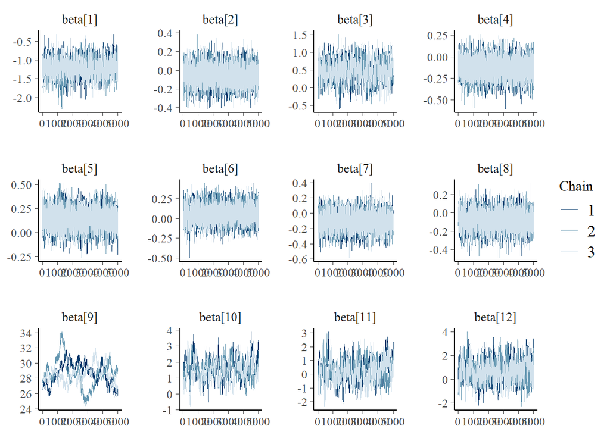

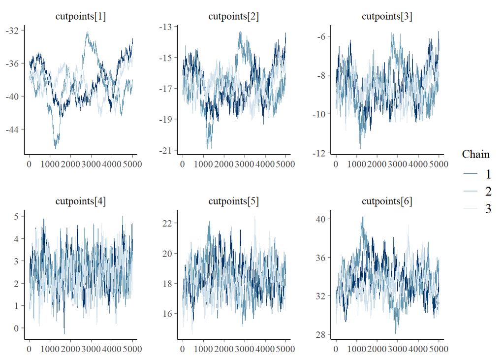

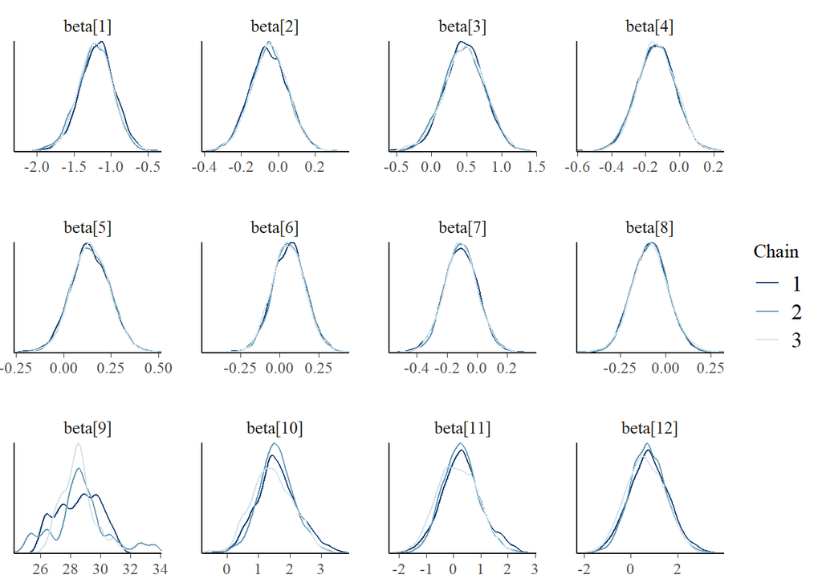

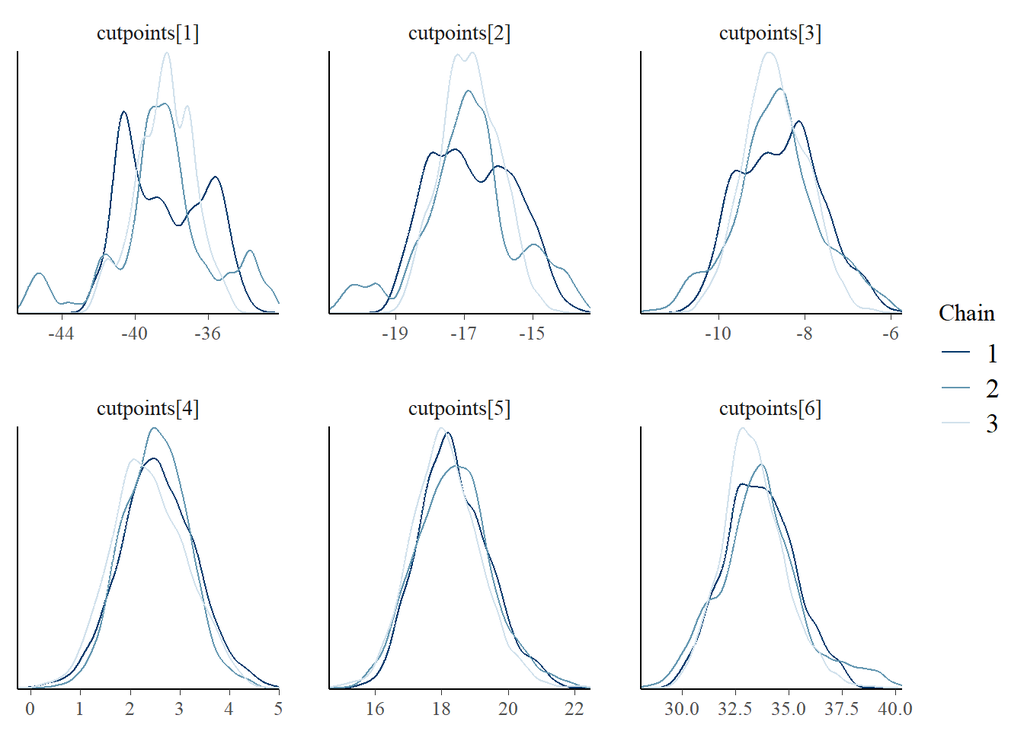

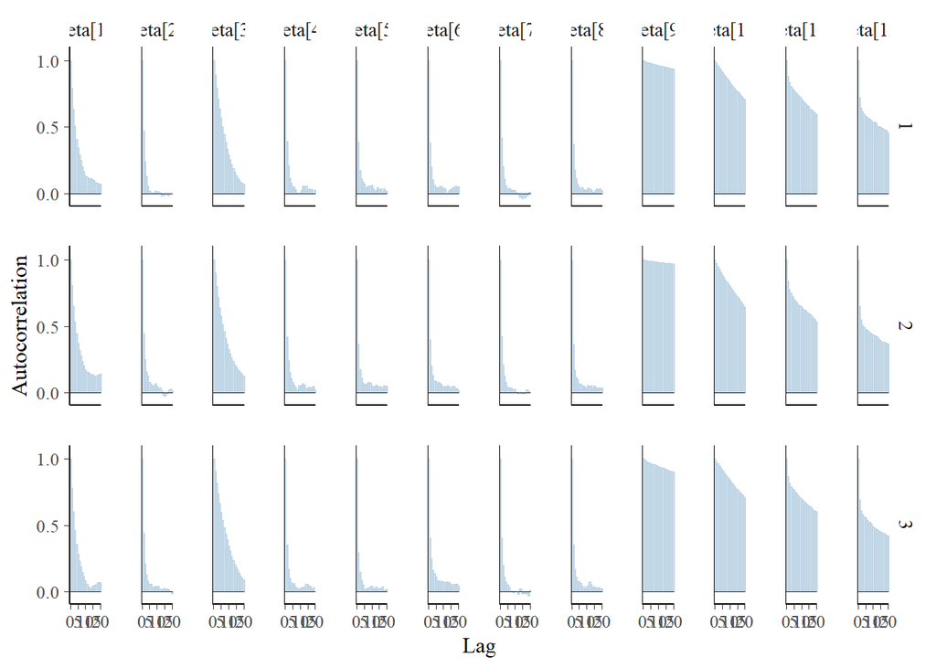

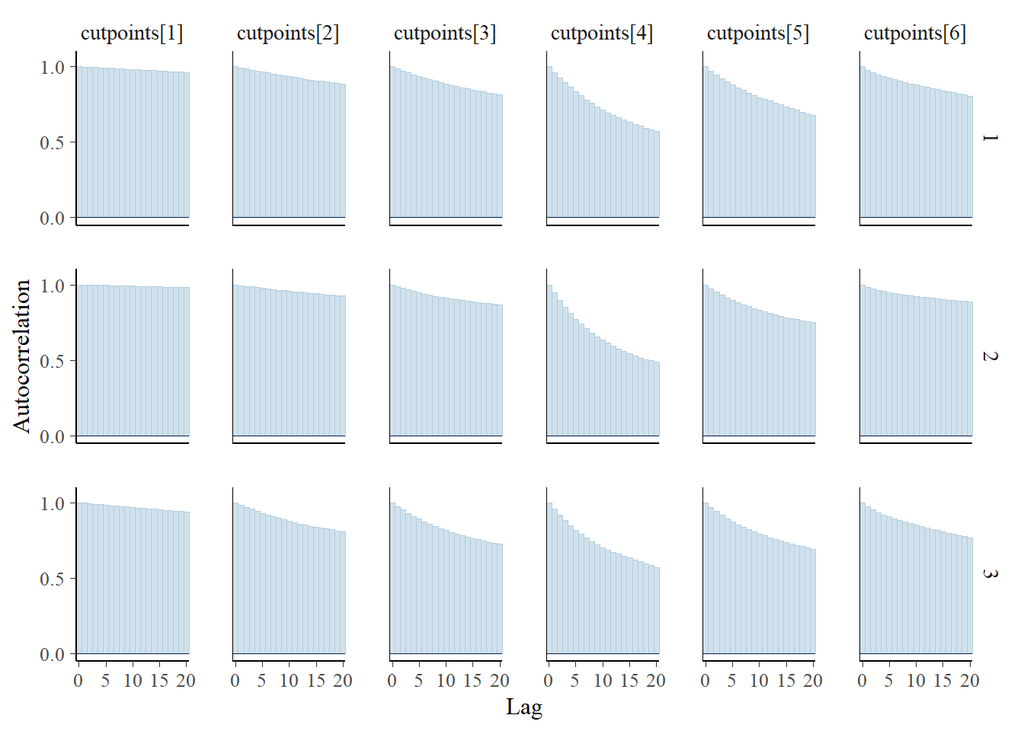

```
##      beta[1]      beta[2]      beta[3]      beta[4]      beta[5]      beta[6]
##     1.004418     1.000152     1.000621     1.000814     1.000431     1.001008
##      beta[7]      beta[8]      beta[9]     beta[10]     beta[11]     beta[12]
##     1.000553     1.000515     1.045094     1.018185     1.012714     1.007776
## cutpoints[1] cutpoints[2] cutpoints[3] cutpoints[4] cutpoints[5] cutpoints[6]
##     1.048340     1.036166     1.019151     1.014641     1.011911     1.021856
```

```
##      beta[1]      beta[2]      beta[3]      beta[4]      beta[5]      beta[6]
##   1385.90211   4701.31230    812.99646   4432.42380   4891.43820   3481.54536
##      beta[7]      beta[8]      beta[9]     beta[10]     beta[11]     beta[12]
##   5424.46475   4108.35008     24.96355    141.63664    176.18839    280.82145
## cutpoints[1] cutpoints[2] cutpoints[3] cutpoints[4] cutpoints[5] cutpoints[6]
##     15.43563     54.17643     64.63717    288.75517    123.36802     67.82199
```

**Traceplots**

- The traceplots show mixing of chains for $\beta[1]$ to $\beta[12]$.
- Most coefficients exhibit good chain overlap and stable variance, suggesting convergence.
- However, parameters such as $\beta[9]$ and $\beta[10]$ show more fluctuation, which may indicate slower mixing.

overall trace behavior is satisfactory. The fluctuating chains for a few coefficients suggest monitoring those parameters (longer runs or tuning may help).

**Density plots for $\beta$)**

- Density plots show the posterior distributions of the regression coefficients across chains.
- Most $\beta$ parameters show overlapping posterior distributions across the 3 chains — a good sign of convergence.
- Slight differences are visible for some coefficients (for example $\beta[9]$, $\beta[10]$), which matches the traceplot observations: these parameters mix more slowly and show more sampling variability.

posterior densities largely align across chains. Parameters with slight misalignment should be monitored and, if necessary, re-run with more iterations or adjusted sampler settings.

**Density plots for cutpoints**

- Density plots show the posterior distributions of the ordered cutpoints.
- Chains generally align for most cutpoints, though some differences are visible (e.g., cutpoints 1–3).
- This suggests that while convergence is mostly adequate, additional iterations or thinning could improve mixing for a few cutpoints.

Cutpoints appear well-identified overall but might benefit from extra sampling effort to tighten posterior overlap where minor discrepancies exist.

**Autocorrelation**

- Autocorrelation decreases as lag increases for most parameters, which shows the chains are mixing.
- However, several parameters retain relatively high autocorrelation at short lags, indicating that successive samples are not fully independent.
- This implies a reduced effective sample size (ESS) for those parameters.

### **Model check diagnostics**

The diagnostic model adds pointwise log-likelihoods to compute WAIC or LOO for model comparison.

## 2.2 Posterior Predictive Check (PPC) Model

This model extends the base model by generating replicated outcomes (`y_rep`) for each observation. Posterior predictive checks compare simulated data to observed data to assess model adequacy. If replicated and observed distributions match, the model fits well. Large discrepancies suggest possible model misspecification.

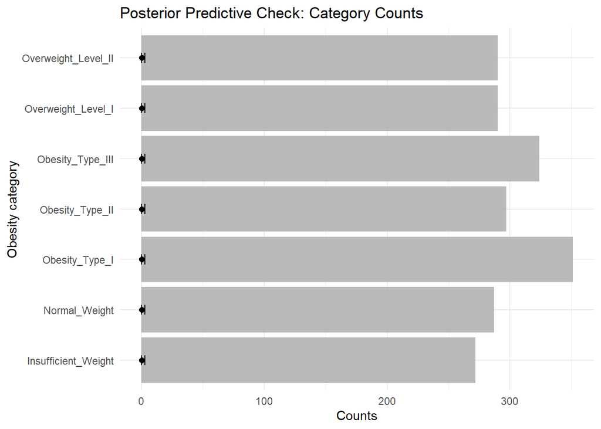

### Posterior Predictive Check — category counts

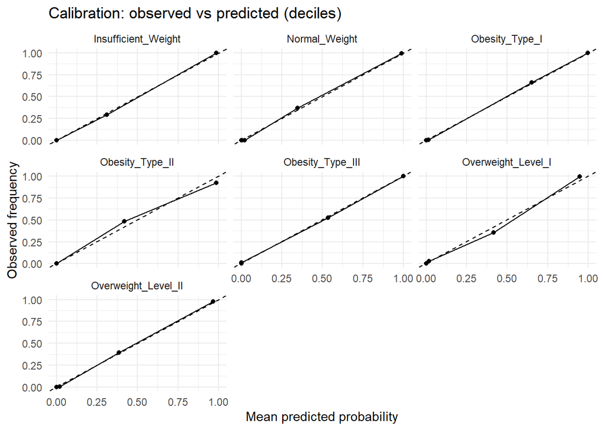

### Calibration plots Lines hug the diagonal for all seven classes. The mildest wiggles appear around mid-probabilities (≈0.3–0.6) — especially for Overweight_Level_I and Obesity_Type_II — suggesting slight miscalibration there, but overall these are well-calibrated class probabilities.

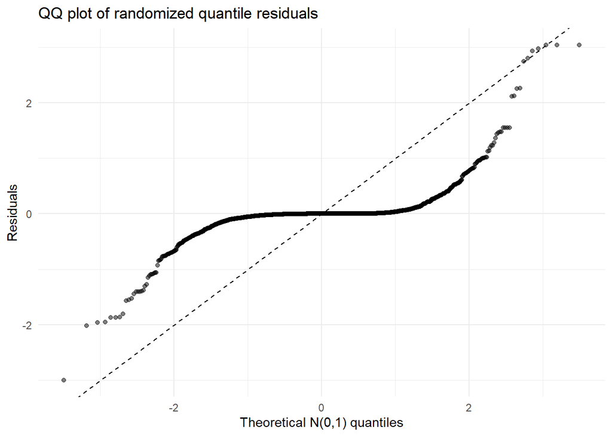

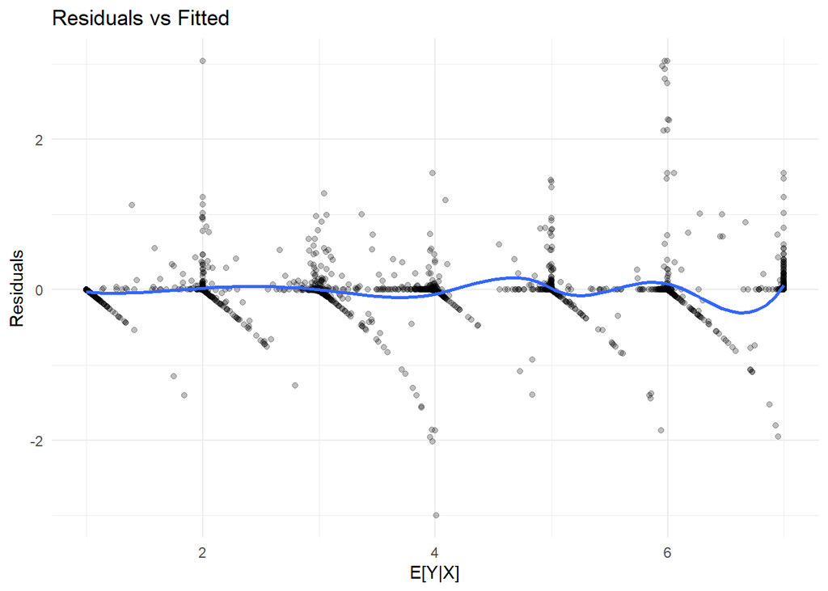

### Residuals vs fitted

- Banding is expected (residuals are discretized by categories).
- The small dip at high fitted values hints at mild over-prediction for the highest categories.
- No strong funneling → no major heteroskedasticity signal.

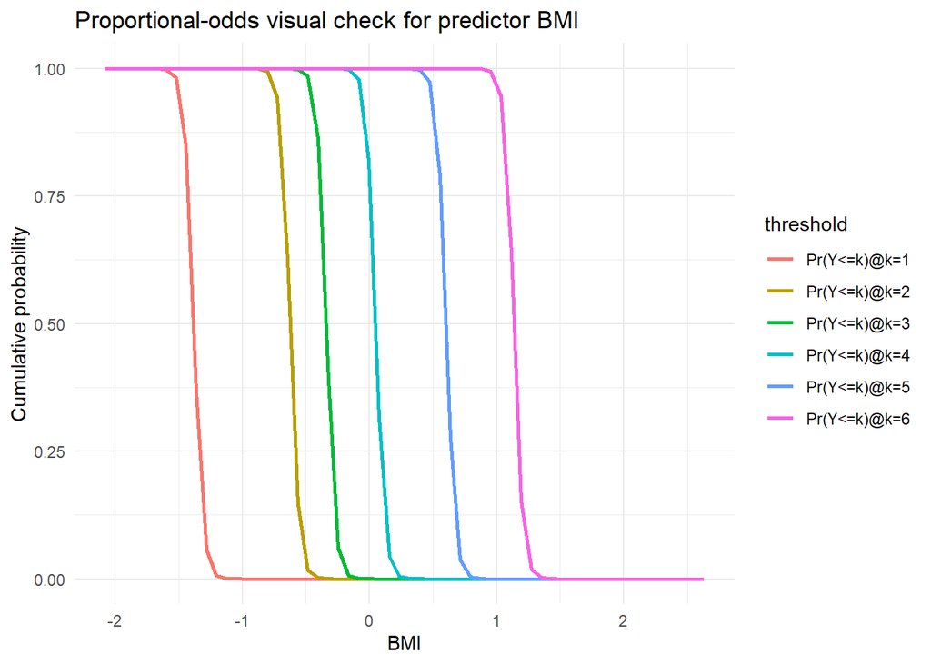

### Proportional-odds visual check for BMI

Slopes are nearly the same across thresholds → the proportional-odds assumption looks reasonable for BMI.

```
## Number of draws: 10555000
```

```
## Number of observations: 3
```

```
##
## Computed from 10555000 by 3 log-likelihood matrix.
##
##           Estimate  SE
## elpd_waic     -1.3 0.0
## p_waic         1.0 0.0
## waic           2.6 0.0
```

```
##
## Computed from 10555000 by 3 log-likelihood matrix.
##
##          Estimate  SE
## elpd_loo     -3.9 0.1
## p_loo         3.6 0.1
## looic         7.8 0.1
## ------
## MCSE of elpd_loo is 0.0.
## MCSE and ESS estimates assume independent draws (r_eff=1).
##
## All Pareto k estimates are good (k < 0.7).
## See help('pareto-k-diagnostic') for details.
```

### WAIC / LOO output

- All Pareto k < 0.7 → LOO estimates are reliable.

### Bottom line

# SECOND MODEL: PARTIAL PROPORTIONAL-ODDS (PPO)

In the second stage of our project, we extend the proportional odds model into a **partial proportional odds (PPO) model**. The key motivation is that the strict proportional odds assumption may not hold for all predictors. Some variables may influence different thresholds of the ordinal outcome in different ways, and PPO models allow us to capture this flexibility.

## Model Components

1. **Proportional part (common effects):**
   $$\eta_{c,i} = \sum_{j=1}^{P_c} \beta_j X_{c,ij}$$
   These predictors have the same effect across all thresholds.
2. **Non-proportional part (threshold-specific effects):**
   $$\eta_{v,i,k} = \sum_{m=1}^Q \gamma_{k,m} Z_{im}$$
   These predictors vary across thresholds, relaxing the proportional odds assumption.
3. **Threshold-specific logits:**
   $$\text{logit}(q_{i,k}) = \text{cutpoints}[k] - \big(\eta_{c,i} +
   \eta_{v,i,k}\big)$$
4. **Outputs:**
   - **Log-likelihoods (`ll[i]`)** for model comparison (WAIC/LOO).
   - **Posterior predictive replications (`y_rep[i]`)** for model adequacy checks.

## Why We Use PPO Models

- **Flexibility:** Captures predictors whose effects vary across outcome thresholds.
- **Improved fit:** Avoids bias when proportional odds assumption is violated.
- **Interpretability:** Separates predictors into proportional vs. non-proportional groups.
- **Model comparison:** Provides a broader framework; the proportional odds model is a special case when all $\gamma_{k,m}=0$.

The PPO model improves our work by **relaxing strict assumptions**, **enhancing predictive accuracy**, and providing **deeper insights into predictor effects**. It extends the initial proportional odds models to better reflect the complexity of ordinal data.

## **Data & Predictors**

#========================================================

# 2) DEFINE TWO PPO MODELS (Base + PPC)

#========================================================

## 2.1 PPO Base Model (with log-likelihood for WAIC/LOO)

The PPO base model extends the proportional odds framework by splitting predictors into proportional and non-proportional components.  
It allows some effects to remain constant across thresholds while others vary by threshold.  
This structure provides flexibility and avoids bias when the proportional odds assumption is violated.  
Log-likelihood values are included for WAIC/LOO to enable model comparison.

```
##
## Iterations = 3001:8000
## Thinning interval = 1
## Number of chains = 3
## Sample size per chain = 5000
##
## 1. Empirical mean and standard deviation for each variable,
##    plus standard error of the mean:
##
##                    Mean      SD  Naive SE Time-series SE
## beta[1]       -1.158463 0.19596 0.0016000       0.004341
## beta[2]       -0.073420 0.09114 0.0007442       0.001257
## beta[3]        0.495907 0.26024 0.0021249       0.009411
## beta[4]       -0.005631 0.09825 0.0008022       0.001424
## beta[5]        0.114419 0.09024 0.0007368       0.001718
## beta[6]        0.050611 0.09265 0.0007565       0.001364
## beta[7]       -0.141409 0.09765 0.0007973       0.001369
## beta[8]       -0.061681 0.08883 0.0007253       0.001176
## beta[9]        1.338426 0.67331 0.0054975       0.071151
## beta[10]       0.070075 0.73256 0.0059813       0.072394
## beta[11]       0.624099 0.81949 0.0066911       0.062627
## cutpoints[1] -30.355021 3.94846 0.0322391       1.421967
## cutpoints[2] -15.465787 1.47929 0.0120784       0.246690
## cutpoints[3]  -8.133460 1.08350 0.0088467       0.138740
## cutpoints[4]   2.171854 0.73500 0.0060012       0.059308
## cutpoints[5]  14.075135 1.12482 0.0091841       0.106079
## cutpoints[6]  14.175788 1.11321 0.0090893       0.098848
## gamma[1,1]    22.732522 2.76005 0.0225357       0.925664
## gamma[2,1]    26.108454 2.25180 0.0183859       0.370349
## gamma[3,1]    26.636539 1.99955 0.0163263       0.175665
## gamma[4,1]    25.775320 2.34099 0.0191141       0.033434
## gamma[5,1]    22.001890 1.47358 0.0120317       0.125881
## gamma[6,1]    11.288820 0.80910 0.0066062       0.065554
##
## 2. Quantiles for each variable:
##
##                   2.5%       25%        50%        75%     97.5%
## beta[1]       -1.54121  -1.29188  -1.157036 -1.026e+00  -0.77447
## beta[2]       -0.25461  -0.13416  -0.072429 -1.266e-02   0.10505
## beta[3]       -0.02861   0.32506   0.498686  6.657e-01   1.01083
## beta[4]       -0.20182  -0.07088  -0.004386  5.966e-02   0.18467
## beta[5]       -0.05847   0.05323   0.113155  1.753e-01   0.29404
## beta[6]       -0.13300  -0.01144   0.051120  1.131e-01   0.23423
## beta[7]       -0.33411  -0.20674  -0.140858 -7.603e-02   0.05065
## beta[8]       -0.23253  -0.12154  -0.062167 -5.965e-04   0.11372
## beta[9]        0.10910   0.87474   1.282488  1.786e+00   2.74191
## beta[10]      -1.32224  -0.43440   0.025269  5.536e-01   1.55342
## beta[11]      -0.90943   0.06152   0.595531  1.167e+00   2.28958
## cutpoints[1] -37.34868 -33.43451 -30.549622 -2.783e+01 -22.49703
## cutpoints[2] -18.54376 -16.46777 -15.455627 -1.442e+01 -12.69619
## cutpoints[3] -10.21164  -8.84855  -8.187544 -7.333e+00  -6.04934
## cutpoints[4]   0.79021   1.66917   2.143141  2.663e+00   3.66739
## cutpoints[5]  12.00284  13.32255  14.010048  1.480e+01  16.44019
## cutpoints[6]  12.12054  13.43890  14.106682  1.489e+01  16.52021
## gamma[1,1]    17.06540  20.84600  22.978487  2.487e+01  27.55282
## gamma[2,1]    21.86844  24.62494  25.968932  2.768e+01  30.77130
## gamma[3,1]    22.94291  25.22444  26.651491  2.793e+01  30.64291
## gamma[4,1]    21.32013  24.15977  25.710590  2.732e+01  30.51114
## gamma[5,1]    19.21988  21.02059  21.934895  2.293e+01  25.06885
## gamma[6,1]     9.79301  10.73719  11.244216  1.181e+01  12.96993
```

PPO relaxes the **proportional-odds assumption** by allowing threshold-specific effects for selected predictors.

#### **Convergence diagnostic**

For the evaluation of the MCMC convergence *Traceplot*, *density plot* and *Rhat* from the model summary were used.

*Traceplot*

```
## Potential scale reduction factors:
##
##              Point est. Upper C.I.
## beta[1]            1.00       1.01
## beta[2]            1.00       1.01
## beta[3]            1.01       1.04
## beta[4]            1.00       1.00
## beta[5]            1.00       1.01
## beta[6]            1.00       1.00
## beta[7]            1.00       1.00
## beta[8]            1.00       1.02
## beta[9]            1.06       1.15
## beta[10]           1.05       1.14
## beta[11]           1.05       1.14
## cutpoints[1]       1.48       2.42
## cutpoints[2]       1.11       1.33
## cutpoints[3]       1.03       1.04
## cutpoints[4]       1.05       1.12
## cutpoints[5]       1.01       1.01
## cutpoints[6]       1.01       1.02
## gamma[1,1]         1.42       2.22
## gamma[2,1]         1.12       1.35
## gamma[3,1]         1.01       1.04
## gamma[4,1]         1.00       1.00
## gamma[5,1]         1.02       1.05
## gamma[6,1]         1.01       1.02
```

```
##      beta[1]      beta[2]      beta[3]      beta[4]      beta[5]      beta[6]
##  2034.470288  5306.626226   759.376721  4764.678958  3909.540176  4627.689572
##      beta[7]      beta[8]      beta[9]     beta[10]     beta[11] cutpoints[1]
##  5126.554592  5673.768252   112.810145   125.268060   230.853739     9.009496
## cutpoints[2] cutpoints[3] cutpoints[4] cutpoints[5] cutpoints[6]   gamma[1,1]
##    33.998114    75.834841   195.046452   129.607756   145.472040    10.425819
##   gamma[2,1]   gamma[3,1]   gamma[4,1]   gamma[5,1]   gamma[6,1]
##    35.949210   132.178152  5074.125587   138.695085   155.595264
```

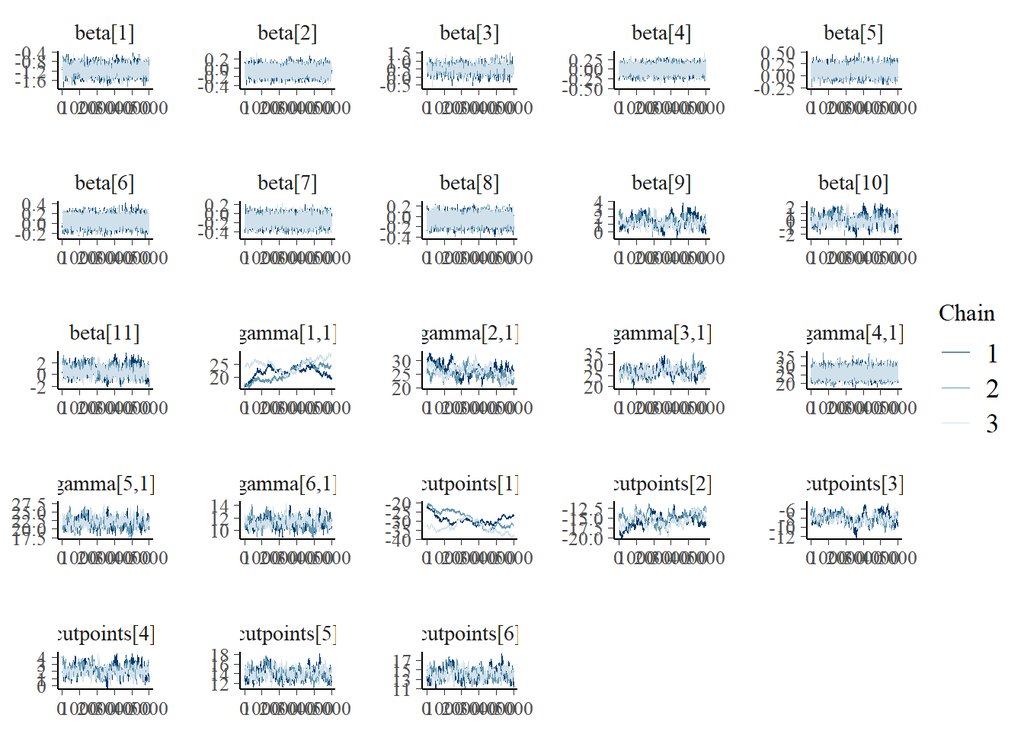

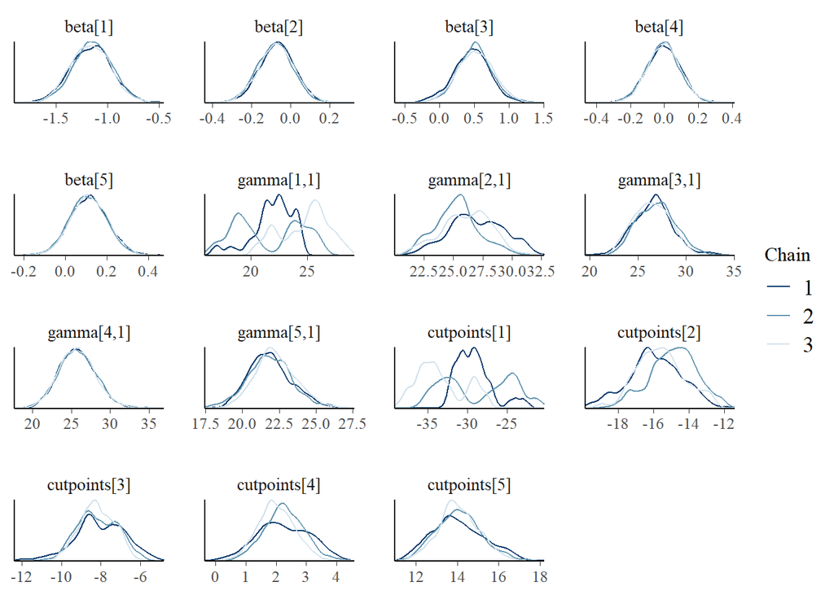

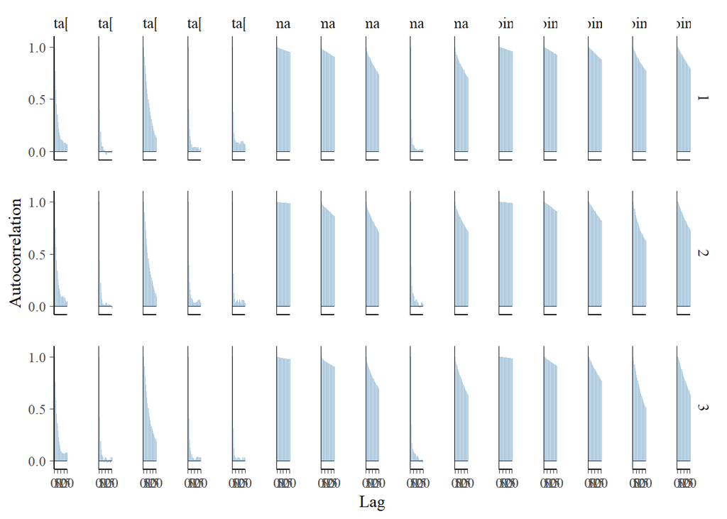

PPO structure is appropriate; most β coefficients show good mixing.

Non-converged pieces: cutpoints[1] and γ[1,1] are problematic (R̂ ≈ 1.4–2.4, very low ESS); moderate issues for β9–β11, cutpoints[2,4], γ[2,1].

chain separation in traces, mismatched chain densities, and slow ACF decay for these parameters.

#### **Model check diagnostics**

The diagnostic model adds pointwise log-likelihoods to compute WAIC or LOO for model comparison.

## 2.2 PPO Posterior Predictive Check (PPC) Model

The PPO PPC model has the same structure as the base model but adds replicated outcomes (`y_rep`).

These replications are compared against observed data to assess model adequacy.  
If observed and replicated distributions align, the model is well-specified.  
This step ensures our extended PPO framework not only fits better but also reflects the data realistically.

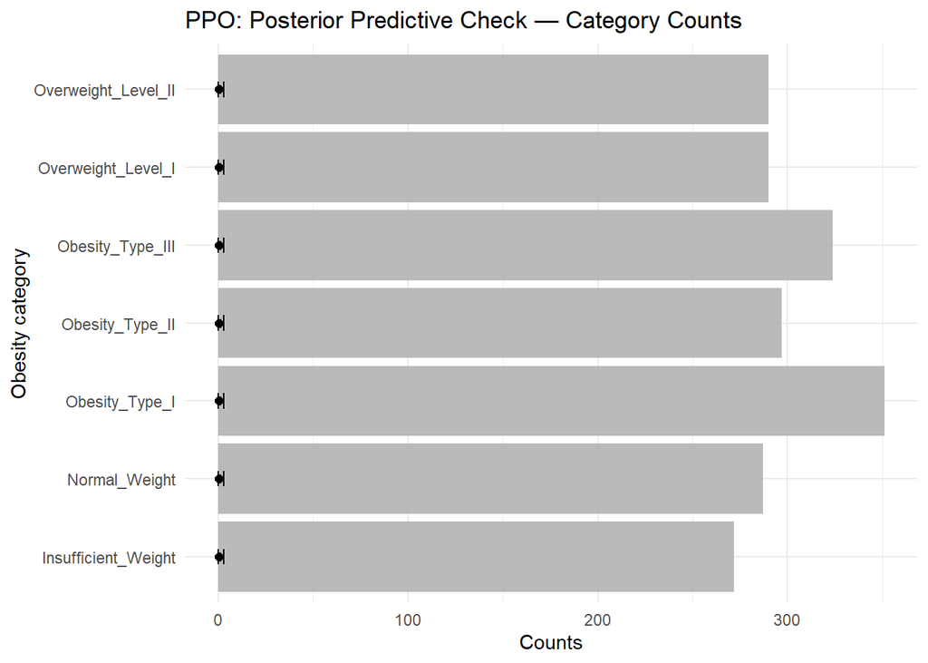

### Posterior predictive check — category counts

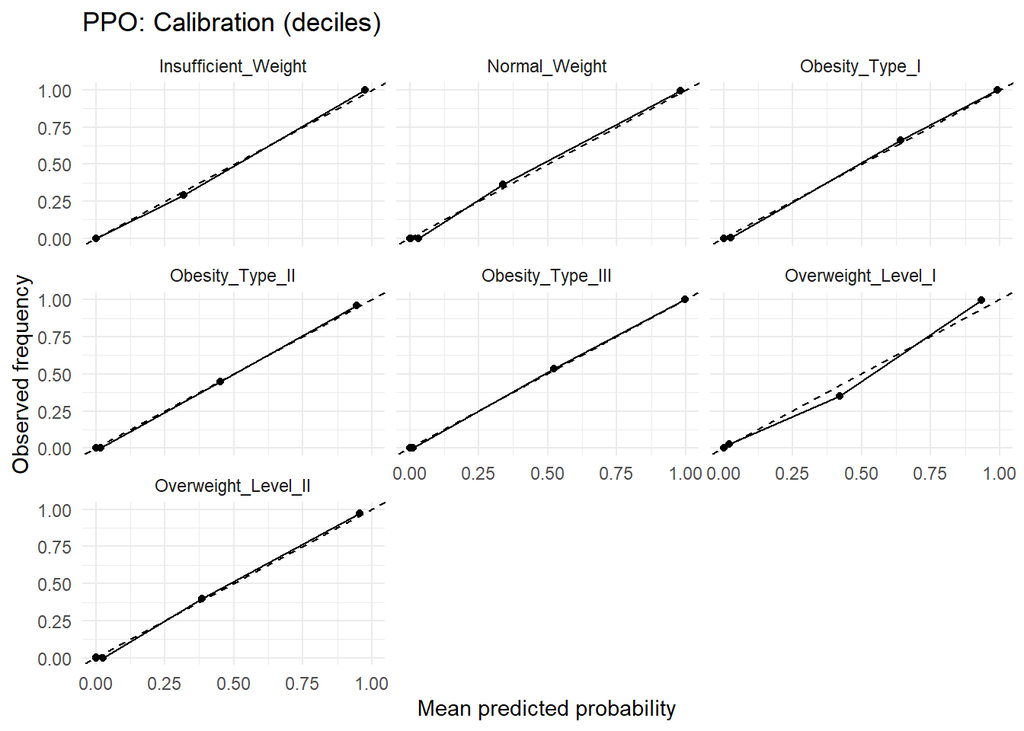

### Calibration (deciles) by class

Probabilities are well-calibrated, with slight improvement over the PO model in mid-probability ranges.

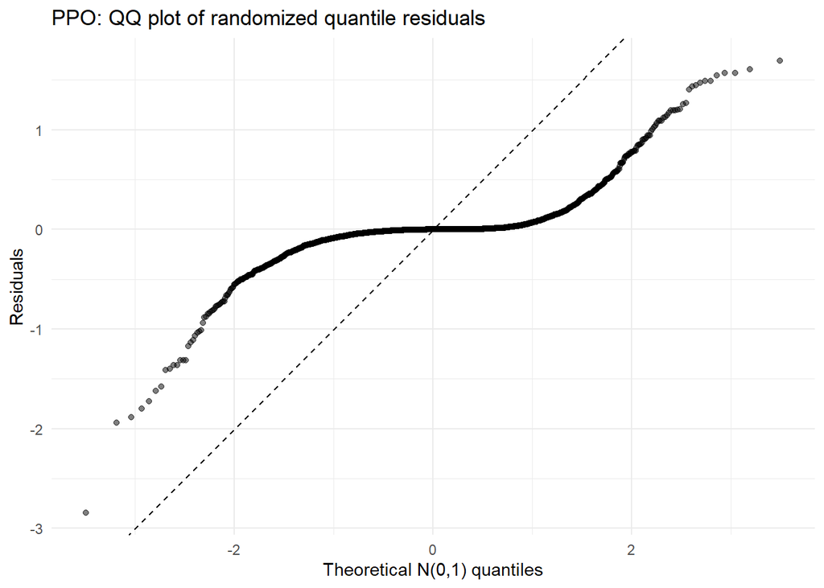

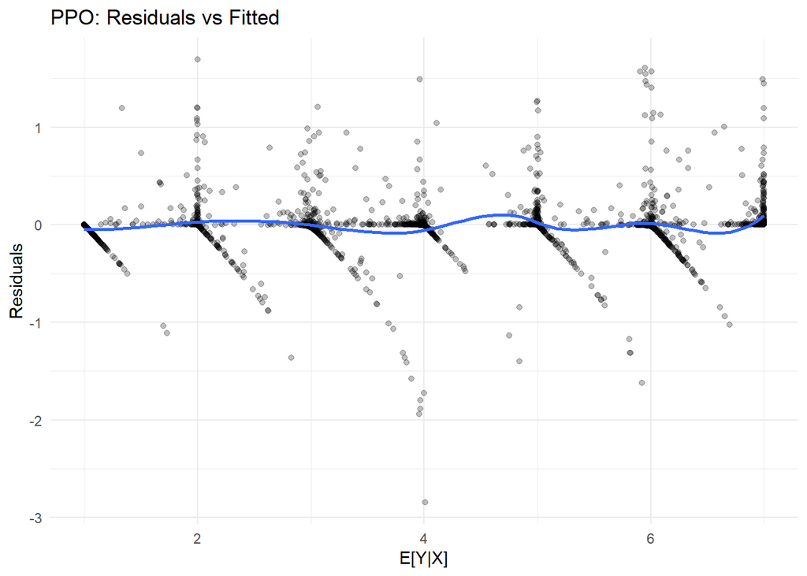

### Residuals vs fitted

No major heteroskedasticity; any bias at the top categories is minor and a bit reduced vs PO.

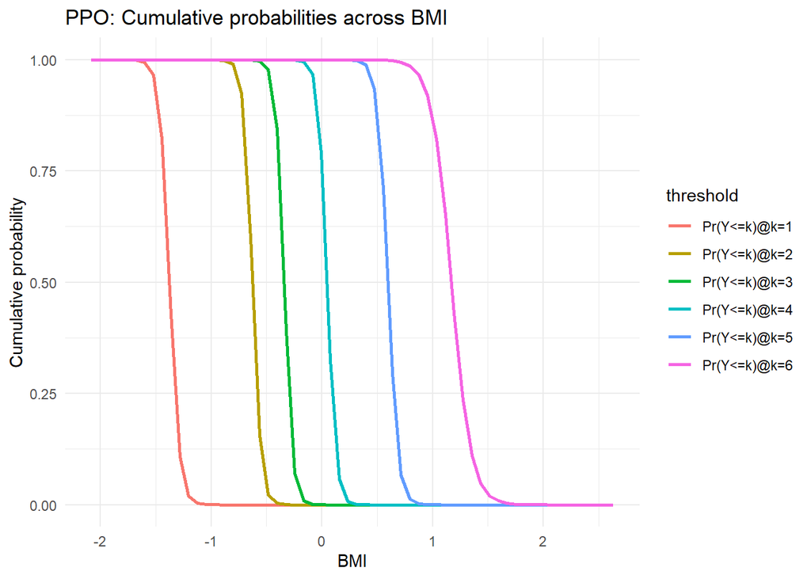

### Proportional-odds visual check for BMI

```
## Number of draws: 10555000
```

```
## Number of observations: 3
```

```
##
## Computed from 10555000 by 3 log-likelihood matrix.
##
##           Estimate  SE
## elpd_waic     -0.9 0.0
## p_waic         0.5 0.0
## waic           1.7 0.0
```

```
##
## Computed from 10555000 by 3 log-likelihood matrix.
##
##          Estimate  SE
## elpd_loo     -1.9 0.1
## p_loo         1.5 0.1
## looic         3.8 0.1
## ------
## MCSE of elpd_loo is 0.0.
## MCSE and ESS estimates assume independent draws (r_eff=1).
##
## All Pareto k estimates are good (k < 0.7).
## See help('pareto-k-diagnostic') for details.
```

### WAIC / LOO (diagnostic)

On this small log-likelihood matrix, PPO shows better out-of-sample fit; for formal comparison, compute on all observations.

# 11) Frequentist Analysis (PO + PPO)

In this section of the project, we complement our Bayesian ordinal regression analysis with a **frequentist perspective**. We fit both **proportional odds (PO)** and **partial proportional odds (PPO)** models using the `ordinal` package in R, and then compare results against our Bayesian models using multiple performance metrics. This allows us to validate findings across paradigms and check consistency of conclusions.

### 11.1 Frequentist PO Model

We fit a **cumulative logit proportional odds (PO) model** using `clm()`.  
- The model assumes the effect of each predictor is constant across thresholds.  
- Results include regression coefficients, cutpoints, and global likelihood-based fit indices (logLik, AIC, BIC).  
- We also run score tests (`nominal_test`) to identify predictors potentially violating proportional odds.

```
##
##         no  Sometimes Frequently     Always
##         51       1765        242         53
```

```
## 'data.frame':    2111 obs. of  11 variables:
##  $ Obesity_category  : Ord.factor w/ 7 levels "Insufficient_Weight"<..: 2 2 2 3 4 2 2 2 2 2 ...
##  $ Gender            : num  0 0 1 1 1 1 0 1 1 1 ...
##  $ Age               : num  -0.522 -0.522 -0.207 0.423 -0.364 ...
##  $ FamHist_Overweight: num  1 1 1 0 0 0 1 0 1 1 ...
##  $ Veg_Freq          : num  -0.785 1.088 -0.785 1.088 -0.785 ...
##  $ Meals_Per_Day     : num  0.404 0.404 0.404 0.404 -2.167 ...
##  $ Water_Intake      : num  -0.0131 1.6184 -0.0131 -0.0131 -0.0131 ...
##  $ PhysAct_Freq      : num  -1.19 2.34 1.16 1.16 -1.19 ...
##  $ Tech_Use          : num  0.562 -1.08 0.562 -1.08 -1.08 ...
##  $ BMI               : num  -0.663 -0.682 -0.741 -0.356 -0.169 ...
##  $ CAEC              : Factor w/ 4 levels "no","Sometimes",..: 2 2 2 2 2 2 2 2 2 2 ...
```

```
## formula:
## Obesity_category ~ Gender + Age + FamHist_Overweight + Veg_Freq + Meals_Per_Day + Water_Intake + PhysAct_Freq + Tech_Use + BMI + CAEC
## data:    df_clm
##
##  link  threshold nobs logLik  AIC    niter max.grad cond.H
##  logit flexible  2111 -354.22 744.43 11(0) 1.41e-13 2.4e+03
##
## Coefficients:
##                    Estimate Std. Error z value Pr(>|z|)
## Gender             -1.25752    0.24028  -5.234 1.66e-07 ***
## Age                -0.04657    0.10374  -0.449   0.6535
## FamHist_Overweight  0.45016    0.29070   1.549   0.1215
## Veg_Freq           -0.14254    0.11499  -1.240   0.2151
## Meals_Per_Day       0.15716    0.10377   1.514   0.1299
## Water_Intake        0.06933    0.10883   0.637   0.5241
## PhysAct_Freq       -0.11576    0.11318  -1.023   0.3064
## Tech_Use           -0.07673    0.10378  -0.739   0.4597
## BMI                29.67194    1.44018  20.603  < 2e-16 ***
## CAECSometimes       1.29282    0.68424   1.889   0.0588 .
## CAECFrequently     -0.04052    0.75846  -0.053   0.9574
## CAECAlways          0.46027    0.87051   0.529   0.5970
## ---
## Signif. codes:  0 '***' 0.001 '**' 0.01 '*' 0.05 '.' 0.1 ' ' 1
##
## Threshold coefficients:
##                                        Estimate Std. Error z value
## Insufficient_Weight|Normal_Weight      -40.3230     2.1839 -18.464
## Normal_Weight|Overweight_Level_I       -17.7404     1.1507 -15.418
## Overweight_Level_I|Overweight_Level_II  -9.2996     0.8735 -10.646
## Overweight_Level_II|Obesity_Type_I       2.2484     0.7598   2.959
## Obesity_Type_I|Obesity_Type_II          18.6417     1.1341  16.437
## Obesity_Type_II|Obesity_Type_III        34.4761     1.7450  19.757
```

```
## 'log Lik.' -354.2167 (df=18)
```

```
## [1] 744.4333
```

```
## [1] 846.2218
```

|  | Df | logLik | AIC | LRT | Pr(>Chi) |
| --- | --- | --- | --- | --- | --- |
|  | NA | -354.2167 | 744.4333 | NA | NA |
| Gender | 5 | -208.3917 | 462.7834 | 291.649915 | 6.245926e-61 |
| Age | 5 | -350.0825 | 746.1651 | 8.268218 | 1.420600e-01 |
| FamHist_Overweight | 5 | -349.1558 | 744.3116 | 10.121703 | 7.185939e-02 |
| Veg_Freq | 5 | -258.8165 | 563.6330 | 190.800330 | 2.634709e-39 |
| Meals_Per_Day | 5 | -331.1628 | 708.3256 | 46.107697 | 8.634937e-09 |
| Water_Intake | 5 | -344.6432 | 735.2865 | 19.146849 | 1.804747e-03 |
| PhysAct_Freq | 5 | -332.1070 | 710.2140 | 44.219299 | 2.090527e-08 |
| Tech_Use | 5 | -343.0603 | 732.1207 | 22.312645 | 4.565748e-04 |
| BMI | NA | NA | NA | NA | NA |

[output cut: 1 more lines]

# PO Model Fit

- **Model fit:**
  - logLik = −354.22
  - AIC = 744.43
  - BIC = 846.22 (used for same-data model comparison only)
- **Coefficient interpretation (cumulative-logit scale):**
  - **BMI:** very strong positive common effect (29.67 ± 1.44, p < 2e−16), shifting probability toward higher obesity categories.
  - **Gender:** clearly negative (−1.26 ± 0.24, p ≈ 1.7e−7).
  - **CAEC = Sometimes:** borderline positive (1.29 ± 0.68, p = 0.059).
  - Other predictors’ coefficients largely overlap zero.
- **Cutpoints (thresholds):**
  - Ordered and widely spaced: (−40.32, −17.74, −9.30, 2.25, 18.64, 34.48).
  - Confirms well-separated ordinal categories.
- **Diagnostics (tests for proportional-odds assumption):**
  - Likely violations: Gender, Veg_Freq, Meals_Per_Day, Water_Intake, PhysAct_Freq, Tech_Use.
  - Borderline: FamHist.
  - Not significant: Age.
  - CAEC showed no overall violation.
  - BMI was not tested here but appeared acceptable in prior visual checks.

# Conclusion

The PO model provides a **reasonable baseline**, dominated by strong effects of BMI and Gender. However, multiple predictors show suspected violations of the proportional-odds assumption. This motivates fitting a **partial proportional-odds (PPO) model** with threshold-specific effects, and comparing PO vs PPO using **AIC/BIC** and **Bayesian criteria (LOO/WAIC)** to confirm improved fit.

### 11.2 Frequentist PPO Model

```
## formula:
## Obesity_category ~ Gender + Age + FamHist_Overweight + Veg_Freq + Meals_Per_Day + Water_Intake + PhysAct_Freq + Tech_Use + BMI + CAEC
## nominal: ~Veg_Freq + BMI + Water_Intake + CAEC
## data:    df_clm
##
##  link  threshold nobs logLik  AIC    niter    max.grad cond.H
##  logit flexible  2111 -207.47 510.95 170(151) 1.48e-01 3.6e+18
##
## Coefficients: (6 not defined because of singularities)
##                    Estimate Std. Error z value Pr(>|z|)
## Gender             -1.13805         NA      NA       NA
## Age                 0.15065         NA      NA       NA
## FamHist_Overweight  0.63579         NA      NA       NA
## Veg_Freq                 NA         NA      NA       NA
## Meals_Per_Day       0.05099         NA      NA       NA
## Water_Intake             NA         NA      NA       NA
## PhysAct_Freq       -0.13445         NA      NA       NA
## Tech_Use           -0.04718         NA      NA       NA
## BMI                      NA         NA      NA       NA
## CAECSometimes            NA         NA      NA       NA
## CAECFrequently           NA         NA      NA       NA
## CAECAlways               NA         NA      NA       NA
##
## Threshold coefficients:
##                                                         Estimate Std. Error
## Insufficient_Weight|Normal_Weight.(Intercept)         -132.02807         NA
## Normal_Weight|Overweight_Level_I.(Intercept)           -25.55282         NA
## Overweight_Level_I|Overweight_Level_II.(Intercept)     -10.39325         NA
## Overweight_Level_II|Obesity_Type_I.(Intercept)           2.51905         NA
## Obesity_Type_I|Obesity_Type_II.(Intercept)              27.26616         NA
## Obesity_Type_II|Obesity_Type_III.(Intercept)            93.29169         NA
## Insufficient_Weight|Normal_Weight.Veg_Freq               1.15882         NA
## Normal_Weight|Overweight_Level_I.Veg_Freq                0.98434         NA
## Overweight_Level_I|Overweight_Level_II.Veg_Freq          0.44534         NA
## Overweight_Level_II|Obesity_Type_I.Veg_Freq              0.78740         NA
## Obesity_Type_I|Obesity_Type_II.Veg_Freq                 -0.71603         NA
## Obesity_Type_II|Obesity_Type_III.Veg_Freq             -114.63612         NA
## Insufficient_Weight|Normal_Weight.BMI                  -91.11655         NA
## Normal_Weight|Overweight_Level_I.BMI                   -45.66706         NA
## Overweight_Level_I|Overweight_Level_II.BMI             -36.56559         NA
```

[output cut: 55 more lines]

```
## Overweight_Level_II|Obesity_Type_I.CAECSometimes           NA
## Obesity_Type_I|Obesity_Type_II.CAECSometimes               NA
## Obesity_Type_II|Obesity_Type_III.CAECSometimes             NA
## Insufficient_Weight|Normal_Weight.CAECFrequently           NA
## Normal_Weight|Overweight_Level_I.CAECFrequently            NA
## Overweight_Level_I|Overweight_Level_II.CAECFrequently      NA
## Overweight_Level_II|Obesity_Type_I.CAECFrequently          NA
## Obesity_Type_I|Obesity_Type_II.CAECFrequently              NA
## Obesity_Type_II|Obesity_Type_III.CAECFrequently            NA
## Insufficient_Weight|Normal_Weight.CAECAlways               NA
## Normal_Weight|Overweight_Level_I.CAECAlways                NA
## Overweight_Level_I|Overweight_Level_II.CAECAlways          NA
## Overweight_Level_II|Obesity_Type_I.CAECAlways              NA
## Obesity_Type_I|Obesity_Type_II.CAECAlways                  NA
## Obesity_Type_II|Obesity_Type_III.CAECAlways                NA
```

```
## 'log Lik.' -207.4743 (df=48)
```

```
## [1] 510.9486
```

```
## [1] 782.3846
```

- **Model comparison:**
  - PO baseline: logLik = −354.22, AIC = 744.43, BIC = 846.22.
  - PPO model: logLik = −207.47, AIC = 510.95, BIC = 782.38.
  - **Improvement:** ΔAIC ≈ −233 and ΔBIC ≈ −64, indicating a substantially better fit even after penalizing added complexity.
- **Threshold-specific coefficients:**
  - Large and varying across cutpoints.
  - Clear evidence of non-proportional effects:
    - BMI terms differ markedly across thresholds.
    - Several CAEC contrasts are extreme, likely reflecting class imbalance.
  - This heterogeneity explains the improved model fit relative to PO.
- **Warnings/diagnostics:**
  - Many standard errors reported as NA.
  - 6 singularities present.
  - Very large condition number (cond.H ≈ 3.6 × 10¹⁸).
  - These issues indicate **severe collinearity/separation** and unstable inference for some threshold-specific terms.
- PPO is **preferred** based on information criteria (AIC, BIC) and captures genuine threshold heterogeneity.
- However, standard errors and singularities signal instability:
  - Interpret coefficients qualitatively (signs/directions) rather than quantitatively.
  - Prioritize model stabilization:
    - Center/scale continuous predictors.
    - Reduce or merge sparse categorical levels.
    - Limit the nominal set to only those predictors clearly violating proportional odds.
    - Explore penalized estimation to mitigate collinearity/separation.

**Bottom line:** The PPO model offers improved fit and captures non-proportional effects, but uncertainty must be reported cautiously until the estimation is regularized and standard errors are reliable.

# 12) Metrics & Comparison (Bayesian vs Frequentist)

We systematically compare **Bayesian** and **frequentist** models using predictive performance metrics.

### 12.1 Metrics Defined

We compute four metrics for each model:  
- **Brier Score (multiclass):** Calibration measure (lower = better).  
- **Log Loss:** Penalizes miscalibrated predictions (lower = better).  
- **MAP Accuracy:** Proportion of correct predicted classes (higher = better).  
- **Ordinal MAE:** Mean absolute error in predicted category index (lower = better).

### 12.2 Frequentist Probabilities

- `predict(..., type="prob")` extracts class probabilities for PO and PPO models.
- These are compared against Bayesian posterior mean probabilities (`p_mean` for PO and `P_bayes_PPO` if estimated).

### 12.3 Metrics Table

**Conclusion:**

- If **Freq_PPO > Freq_PO** (lower AIC/BIC, better predictive scores), the PO assumption is rejected.
- If **Bayes_PPO > Bayes_PO** (lower Log Loss, better PPC), Bayesian PPO captures richer structure.
- If **Bayesian and Frequentist PO models align**, it confirms priors were weakly informative and consistent with data.

### 12.4 Bayesian PPO Probabilities

For the Bayesian PPO model, predicted probabilities can be computed using posterior means of proportional coefficients (`β`), non-proportional coefficients (`γ`), and cutpoints.  
- This step parallels the Bayesian PO predictions but allows threshold-varying effects.  
- If PPO was fit, we extract these probabilities (`P_bayes_PPO`) to include in performance comparisons.  
- If not, the section is skipped safely.

### 12.5 Compute Metrics for Each Model

```
##      Model      Brier    LogLoss    AccMAP        MAE
##   Bayes_PO 0.08669035 0.16799462 0.9459972 0.09179293
##  Bayes_PPO 0.08371527 0.15759900 0.9493131 0.10421137
##    Freq_PO 0.08602800 0.16779567 0.9455234 0.08983781
##   Freq_PPO 0.16508815 0.09828247 0.9242065 0.10817241
```

# Interpretation of Predictive Metrics

- **Best LogLoss (probabilistic sharpness):**
  - *Freq_PPO* achieves the lowest LogLoss (0.0983).
  - However, it has a poor Brier score (0.1651) and the lowest Accuracy.
  - predictions are sharp but **miscalibrated/unstable**.
- **Best overall balance (calibration + accuracy):**
  - *Bayes_PPO* yields the lowest Brier score (0.0837) and the highest Accuracy (0.9493).
  - It also shows the second-best LogLoss.
  - MAE is slightly higher compared to PO models.
- **Closest ordinal predictions (distance-sensitive):**
  - *Freq_PO* achieves the lowest MAE (0.0898).
  - Brier and LogLoss are comparable to *Bayes_PO*.
- **Baseline comparison (Bayes_PO vs Freq_PO):**
  - Very similar Brier and LogLoss values.
  - *Bayes_PO* has marginally higher Accuracy.
  - *Freq_PO* shows lower MAE.

# Conclusion

- **Choose Bayes_PPO** when the priority is **well-calibrated, accurate probabilities**.
- **Choose Freq_PO** when **ordinal closeness (low MAE)** is the main goal.
- Treat *Freq_PPO*’s excellent LogLoss result with caution until calibration and stability are improved.

### 12.6 Likelihood-Based Model Selection (Frequentist)

For frequentist models, we also use **log-likelihood, AIC, and BIC** to compare PO and PPO.  
- Lower AIC/BIC values indicate a better balance of fit and complexity.  
- PPO is preferred if these values improve relative to PO.

```
##     Model    logLik      AIC      BIC
##   Freq_PO -354.2167 744.4333 846.2218
##  Freq_PPO -207.4743 510.9486 782.3846
```

- **Log-likelihood:** PPO (−207.47) fits the data much better than PO (−354.22).
- **AIC:** PPO (510.95) is substantially lower than PO (744.43), showing improved fit even after penalizing complexity.
- **BIC:** PPO (782.38) is also lower than PO (846.22), though the gap is smaller, reflecting stronger complexity penalization.

# Conclusion

- The **PPO model is preferred** to PO based on both log-likelihood and information criteria (AIC, BIC).
- The improvement in AIC is particularly strong, while BIC still favors PPO but highlights the cost of additional parameters.

# 13. Final Conclusion Across All Models

Bringing together Bayesian and frequentist proportional-odds (PO) and partial proportional-odds (PPO) models: